# Practice_Linear Regression_USA Housing Data

## This is mostly just code for reference. Please watch the video lecture for more info behind all of this code.

Your neighbor is a real estate agent and wants some help predicting housing prices for regions in the USA. It would be great if you could somehow create a model for her that allows her to put in a few features of a house and returns back an estimate of what the house would sell for.

She has asked you if you could help her out with your new data science skills. You say yes, and decide that Linear Regression might be a good path to solve this problem!

Your neighbor then gives you some information about a bunch of houses in regions of the United States,it is all in the data set: USA_Housing.csv.

The data contains the following columns:

'Avg. Area Income': Avg. Income of residents of the city house is located in. 'Avg. Area House Age': Avg Age of Houses in same city 'Avg. Area Number of Rooms': Avg Number of Rooms for Houses in same city 'Avg. Area Number of Bedrooms': Avg Number of Bedrooms for Houses in same city 'Area Population': Population of city house is located in 'Price': Price that the house sold at 'Address': Address for the house

```python
import numpy as np
import pandas as pd
import matplotlib.pyplot as plt
%matplotlib inline
```

```python
import seaborn as sns
```

```python
df = pd.read_csv("USA_Housing.csv")
df.head()
```

|  | Avg. Area Income | Avg. Area House Age | Avg. Area Number of Rooms | Avg. Area Number of Bedrooms | Area Population | Price | Address |
| --- | --- | --- | --- | --- | --- | --- | --- |
| 0 | 79545.458574 | 5.682861 | 7.009188 | 4.09 | 23086.800503 | 1.059034e+06 | 208 Michael Ferry Apt. 674\nLaurabury, NE 3701... |
| 1 | 79248.642455 | 6.002900 | 6.730821 | 3.09 | 40173.072174 | 1.505891e+06 | 188 Johnson Views Suite 079\nLake Kathleen, CA... |
| 2 | 61287.067179 | 5.865890 | 8.512727 | 5.13 | 36882.159400 | 1.058988e+06 | 9127 Elizabeth Stravenue\nDanieltown, WI 06482... |
| 3 | 63345.240046 | 7.188236 | 5.586729 | 3.26 | 34310.242831 | 1.260617e+06 | USS Barnett\nFPO AP 44820 |
| 4 | 59982.197226 | 5.040555 | 7.839388 | 4.23 | 26354.109472 | 6.309435e+05 | USNS Raymond\nFPO AE 09386 |

```python
df.info()
```

```
<class 'pandas.core.frame.DataFrame'>
RangeIndex: 5000 entries, 0 to 4999
Data columns (total 7 columns):
 #   Column                        Non-Null Count  Dtype
---  ------                        --------------  -----
 0   Avg. Area Income              5000 non-null   float64
 1   Avg. Area House Age           5000 non-null   float64
 2   Avg. Area Number of Rooms     5000 non-null   float64
 3   Avg. Area Number of Bedrooms  5000 non-null   float64
 4   Area Population               5000 non-null   float64
 5   Price                         5000 non-null   float64
 6   Address                       5000 non-null   object
dtypes: float64(6), object(1)
memory usage: 273.6+ KB
```

```python
df.describe()
```

|  | Avg. Area Income | Avg. Area House Age | Avg. Area Number of Rooms | Avg. Area Number of Bedrooms | Area Population | Price |
| --- | --- | --- | --- | --- | --- | --- |
| count | 5000.000000 | 5000.000000 | 5000.000000 | 5000.000000 | 5000.000000 | 5.000000e+03 |
| mean | 68583.108984 | 5.977222 | 6.987792 | 3.981330 | 36163.516039 | 1.232073e+06 |
| std | 10657.991214 | 0.991456 | 1.005833 | 1.234137 | 9925.650114 | 3.531176e+05 |
| min | 17796.631190 | 2.644304 | 3.236194 | 2.000000 | 172.610686 | 1.593866e+04 |
| 25% | 61480.562388 | 5.322283 | 6.299250 | 3.140000 | 29403.928702 | 9.975771e+05 |
| 50% | 68804.286404 | 5.970429 | 7.002902 | 4.050000 | 36199.406689 | 1.232669e+06 |
| 75% | 75783.338666 | 6.650808 | 7.665871 | 4.490000 | 42861.290769 | 1.471210e+06 |
| max | 107701.748378 | 9.519088 | 10.759588 | 6.500000 | 69621.713378 | 2.469066e+06 |

```python
df.isnull()
```

|  | Avg. Area Income | Avg. Area House Age | Avg. Area Number of Rooms | Avg. Area Number of Bedrooms | Area Population | Price | Address |
| --- | --- | --- | --- | --- | --- | --- | --- |
| 0 | False | False | False | False | False | False | False |
| 1 | False | False | False | False | False | False | False |
| 2 | False | False | False | False | False | False | False |
| 3 | False | False | False | False | False | False | False |
| 4 | False | False | False | False | False | False | False |
| ... | ... | ... | ... | ... | ... | ... | ... |
| 4995 | False | False | False | False | False | False | False |
| 4996 | False | False | False | False | False | False | False |
| 4997 | False | False | False | False | False | False | False |
| 4998 | False | False | False | False | False | False | False |
| 4999 | False | False | False | False | False | False | False |

5000 rows × 7 columns

# EDA

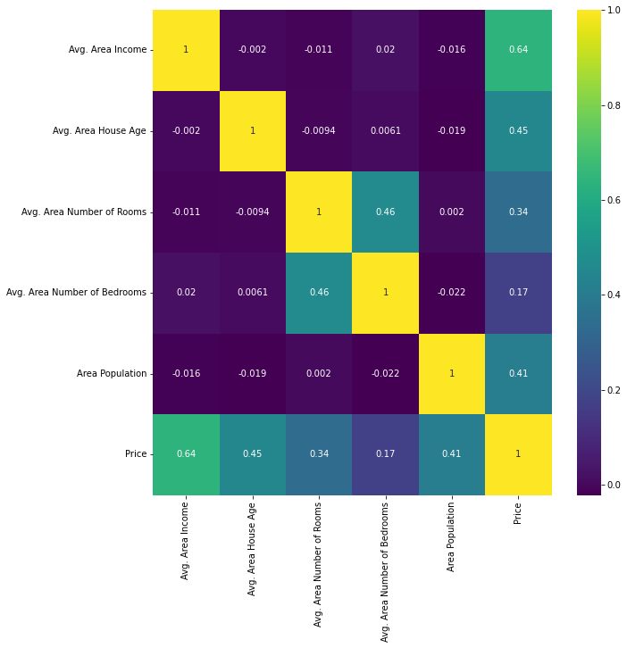

```python
plt.figure(figsize=(10,10))
sns.heatmap(df.corr(), cmap='viridis', annot=True)
```

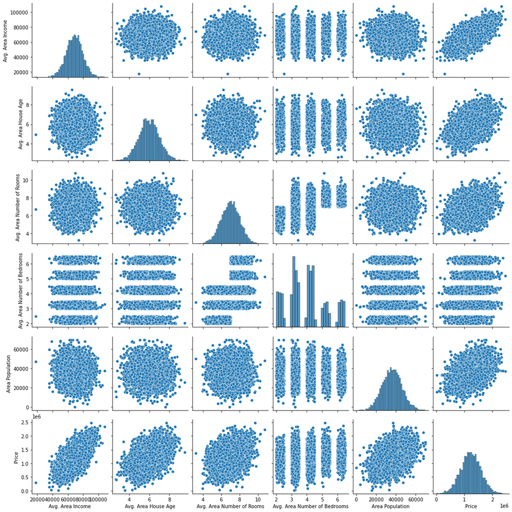

```python
sns.pairplot(df)
```

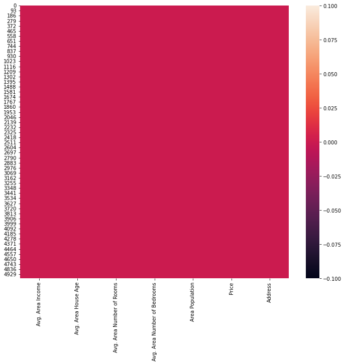

```python
plt.figure(figsize=(12,10))
sns.heatmap(df.isnull())
```

```python
# We see that the address is all string but the most useful data perhaps would be Zip code and see how price distribution
# is affected by zip code.

df['Address']
```

```
0       208 Michael Ferry Apt. 674\nLaurabury, NE 3701...
1       188 Johnson Views Suite 079\nLake Kathleen, CA...
2       9127 Elizabeth Stravenue\nDanieltown, WI 06482...
3                               USS Barnett\nFPO AP 44820
4                              USNS Raymond\nFPO AE 09386
                              ...
4995                     USNS Williams\nFPO AP 30153-7653
4996                PSC 9258, Box 8489\nAPO AA 42991-3352
4997    4215 Tracy Garden Suite 076\nJoshualand, VA 01...
4998                            USS Wallace\nFPO AE 73316
4999    37778 George Ridges Apt. 509\nEast Holly, NV 2...
Name: Address, Length: 5000, dtype: object
```

```python
for address in df['Address']:
    print(f'Address is : {address}\n')
```

[output not shown]

[output cut: 14944 more lines]

[output not shown]

```python
df['Zip Address'] = df['Address'].apply(lambda Address: Address.split(" ")[-1])
```

```python
df['Zip Address']
```

```
0       37010-5101
1            48958
2       06482-3489
3            44820
4            09386
           ...
4995    30153-7653
4996    42991-3352
4997    01707-9165
4998         73316
4999    29290-3595
Name: Zip Address, Length: 5000, dtype: object
```

```python
df['Zip Address'].nunique()
```

```
4958
```

# I will do 2 versions below, with Scaled Data v/s Non scaled Data to see what works better

```python
# Since there are almost 5000 unique zip addresses, we may not be able to make much use of the Zip address. My intention was t0
# check if ZIP code relates to Price of the property. Clearly the Zip code is all unique, adding this detail in the data will
# not be of much use. hence we can drop the idea.
```

```python
# Additionally, let's see if we can do any Normalization on the other data that are way too spaced. Like prices and area pupulation.
# Its a good idea to normalize the data in order for the data to be on same scale.
# A lot of methods can be used here say : MinMaxScalar or Standard Scalar
# I will use a copy of the df data frame to make these edits
```

```python
from sklearn.preprocessing import MinMaxScaler
```

```python
import copy
from copy import deepcopy
```

```python
df_new = deepcopy(df)
```

```python
df_new.head()
```

|  | Avg. Area Income | Avg. Area House Age | Avg. Area Number of Rooms | Avg. Area Number of Bedrooms | Area Population | Price | Address | Zip Address |
| --- | --- | --- | --- | --- | --- | --- | --- | --- |
| 0 | 79545.458574 | 5.682861 | 7.009188 | 4.09 | 23086.800503 | 1.059034e+06 | 208 Michael Ferry Apt. 674\nLaurabury, NE 3701... | 37010-5101 |
| 1 | 79248.642455 | 6.002900 | 6.730821 | 3.09 | 40173.072174 | 1.505891e+06 | 188 Johnson Views Suite 079\nLake Kathleen, CA... | 48958 |
| 2 | 61287.067179 | 5.865890 | 8.512727 | 5.13 | 36882.159400 | 1.058988e+06 | 9127 Elizabeth Stravenue\nDanieltown, WI 06482... | 06482-3489 |
| 3 | 63345.240046 | 7.188236 | 5.586729 | 3.26 | 34310.242831 | 1.260617e+06 | USS Barnett\nFPO AP 44820 | 44820 |
| 4 | 59982.197226 | 5.040555 | 7.839388 | 4.23 | 26354.109472 | 6.309435e+05 | USNS Raymond\nFPO AE 09386 | 09386 |

```python
from sklearn.model_selection import train_test_split
from sklearn.linear_model import LinearRegression
from sklearn.metrics import confusion_matrix
```

```python
df_new.drop(['Address', 'Zip Address'], axis=1, inplace=True)
```

```python
scaler = MinMaxScaler()
```

```python
model = scaler.fit(df_new)
scaled_data = model.transform(df_new)
```

```python
scaled_data
```

```
array([[0.68682217, 0.44198584, 0.50150158, 0.46444444, 0.3299422 ,
        0.42521032],
       [0.68352073, 0.48853836, 0.46450137, 0.24222222, 0.57596801,
        0.60736859],
       [0.48373705, 0.46860901, 0.70135011, 0.69555556, 0.52858204,
        0.42519175],
       ...,
       [0.50713527, 0.67002636, 0.20853446, 0.02888889, 0.47651494,
        0.41367241],
       [0.55841872, 0.4203891 , 0.51757886, 0.76444444, 0.61128233,
        0.48212679],
       [0.53071451, 0.48699729, 0.47267788, 0.46      , 0.66708815,
        0.52301078]])
```

```python
df_new_scaled = deepcopy(df_new)
df_new_scaled[df_new.columns] = scaler.fit_transform(df_new[df_new.columns])
print(df_new_scaled)
```

```
      Avg. Area Income  Avg. Area House Age  Avg. Area Number of Rooms  \
0             0.686822             0.441986                   0.501502
1             0.683521             0.488538                   0.464501
2             0.483737             0.468609                   0.701350
3             0.506630             0.660956                   0.312430
4             0.469223             0.348556                   0.611851
...                ...                  ...                        ...
4995          0.475738             0.754359                   0.385619
4996          0.675097             0.633450                   0.444024
4997          0.507135             0.670026                   0.208534
4998          0.558419             0.420389                   0.517579
4999          0.530715             0.486997                   0.472678

      Avg. Area Number of Bedrooms  Area Population     Price
0                         0.464444         0.329942  0.425210
1                         0.242222         0.575968  0.607369
2                         0.695556         0.528582  0.425192
3                         0.280000         0.491549  0.507384
4                         0.495556         0.376988  0.250702
...                            ...              ...       ...
4995                      0.324444         0.326351  0.425683
4996                      0.448889         0.366362  0.597881
4997                      0.028889         0.476515  0.413672
4998                      0.764444         0.611282  0.482127
4999                      0.460000         0.667088  0.523011

[5000 rows x 6 columns]
```

```python
df_new_scaled.columns
```

```
Index(['Avg. Area Income', 'Avg. Area House Age', 'Avg. Area Number of Rooms',
       'Avg. Area Number of Bedrooms', 'Area Population', 'Price'],
      dtype='object')
```

```python
X = df_new_scaled.drop('Price', axis=1)
y = df_new_scaled['Price']
```

```python
X_train, X_test, y_train, y_test = train_test_split(X, y, test_size=0.3, random_state=101)
```

```python
lin_reg = LinearRegression()
```

```python
lin_reg.fit(X_train, y_train)
```

```
LinearRegression()
```

```python
lin_reg.coef_
```

```
array([0.79226883, 0.46302516, 0.37233317, 0.00241905, 0.43103198])
```

```python
lin_reg.intercept_
```

```
-0.5860025035145763
```

```python
coeff_df = pd.DataFrame(lin_reg.coef_,X.columns,columns=['Coefficient'])
coeff_df
```

|  | Coefficient |
| --- | --- |
| Avg. Area Income | 0.792269 |
| Avg. Area House Age | 0.463025 |
| Avg. Area Number of Rooms | 0.372333 |
| Avg. Area Number of Bedrooms | 0.002419 |
| Area Population | 0.431032 |

```python
y_pred = lin_reg.predict(X_test)
```

```python
y_pred
```

```
array([0.5066987 , 0.32886842, 0.7037042 , ..., 0.58566162, 0.25675739,
       0.54991247])
```

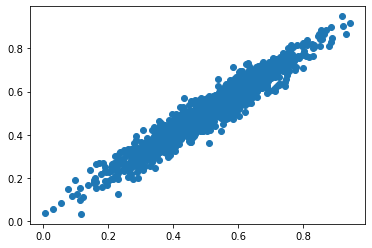

```python
plt.scatter(y_test,y_pred)
```

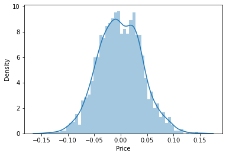

```python
sns.distplot((y_test-y_pred),bins=50);
```

```python
from sklearn import metrics
```

```python
print('MAE  :', metrics.mean_absolute_error(y_test, y_pred))
print('MSE  :', metrics.mean_squared_error(y_test, y_pred))
print('RMSE :', np.sqrt(metrics.mean_squared_error(y_test, y_pred)))
```

```
MAE  : 0.03312407391471072
MSE  : 0.0016898321459283064
RMSE : 0.04110756798848974
```

# Now, let's see how this works without scaling

```python
df_new
```

|  | Avg. Area Income | Avg. Area House Age | Avg. Area Number of Rooms | Avg. Area Number of Bedrooms | Area Population | Price |
| --- | --- | --- | --- | --- | --- | --- |
| 0 | 79545.458574 | 5.682861 | 7.009188 | 4.09 | 23086.800503 | 1.059034e+06 |
| 1 | 79248.642455 | 6.002900 | 6.730821 | 3.09 | 40173.072174 | 1.505891e+06 |
| 2 | 61287.067179 | 5.865890 | 8.512727 | 5.13 | 36882.159400 | 1.058988e+06 |
| 3 | 63345.240046 | 7.188236 | 5.586729 | 3.26 | 34310.242831 | 1.260617e+06 |
| 4 | 59982.197226 | 5.040555 | 7.839388 | 4.23 | 26354.109472 | 6.309435e+05 |
| ... | ... | ... | ... | ... | ... | ... |
| 4995 | 60567.944140 | 7.830362 | 6.137356 | 3.46 | 22837.361035 | 1.060194e+06 |
| 4996 | 78491.275435 | 6.999135 | 6.576763 | 4.02 | 25616.115489 | 1.482618e+06 |
| 4997 | 63390.686886 | 7.250591 | 4.805081 | 2.13 | 33266.145490 | 1.030730e+06 |
| 4998 | 68001.331235 | 5.534388 | 7.130144 | 5.44 | 42625.620156 | 1.198657e+06 |
| 4999 | 65510.581804 | 5.992305 | 6.792336 | 4.07 | 46501.283803 | 1.298950e+06 |

5000 rows × 6 columns

```python
X = df_new.drop('Price', axis=1)
```

```python
y = df_new["Price"]
```

```python
X_train, X_test, y_train, y_test = train_test_split(X, y, test_size=0.3, random_state=101)
```

```python
lin_reg_non_scaled = LinearRegression()
```

```python
lin_reg_non_scaled.fit(X_train, y_train)
```

```
LinearRegression()
```

```python
y_pred = lin_reg_non_scaled.predict(X_test)
```

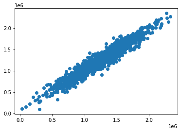

```python
plt.scatter(y_test, y_pred)
```

```python
coeff_df = pd.DataFrame(lin_reg_non_scaled.coef_,X.columns,columns=['Coefficient'])
coeff_df
```

|  | Coefficient |
| --- | --- |
| Avg. Area Income | 21.617635 |
| Avg. Area House Age | 165221.119872 |
| Avg. Area Number of Rooms | 121405.376596 |
| Avg. Area Number of Bedrooms | 1318.718783 |
| Area Population | 15.225196 |

Interpreting the coefficients:

Holding all other features fixed, a 1 unit increase in Avg. Area Income is associated with an *increase of $21.617635*

Holding all other features fixed, a 1 unit increase in Avg. Area House Age is associated with an *increase of $165221.119872*

Holding all other features fixed, a 1 unit increase in Avg. Area Number of Rooms is associated with an *increase of $121405.376596*

Holding all other features fixed, a 1 unit increase in Avg. Area Number of Bedrooms is associated with an *increase of $1318.718783*

```python
print('MAE  :', metrics.mean_absolute_error(y_test, y_pred))
print('MSE  :', metrics.mean_squared_error(y_test, y_pred))
print('RMSE :', np.sqrt(metrics.mean_squared_error(y_test, y_pred)))
```

```
MAE  : 81257.5579585586
MSE  : 10169125565.897495
RMSE : 100842.08231634993
```

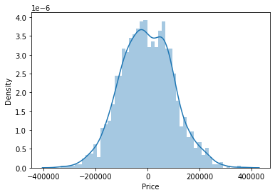

```python
sns.distplot((y_test-y_pred),bins=50);
```

## So we see that the relation ship between the scaled data and non scaled data wrt to the Linear Regression remains same. Hence, we can conclude here.